# Markdown - Aula 0

Fabrício Venturim

2023-04-25

```r
# Rode se não tiver instalado
# install.packages("utf8")
```

```r
library(utf8)
Sys.setlocale("LC_CTYPE", "en_US.UTF-8")
```

```
## [1] "en_US.UTF-8"
```

# 1 Criando um arquivo R markdown

O R Markdown é a junção da linguagem Markdown com o poder de códigos em R.

O caminho para criar um arquivo R markdown é: `File > New File > R Markdown`.

Uma janela será aberta, chamada New R Markdown. Coloque um título, um autor, selecione o HTML e clique em ok.

Agora, quando quiser gerar o HTML do seu arquivo, basta cliar em `Knit` na barra.

[figure not shown]

[figure not shown]

# 2 Estrutura do arquivo R Markdown

```r
1 + 1
```

```
## [1] 2
```

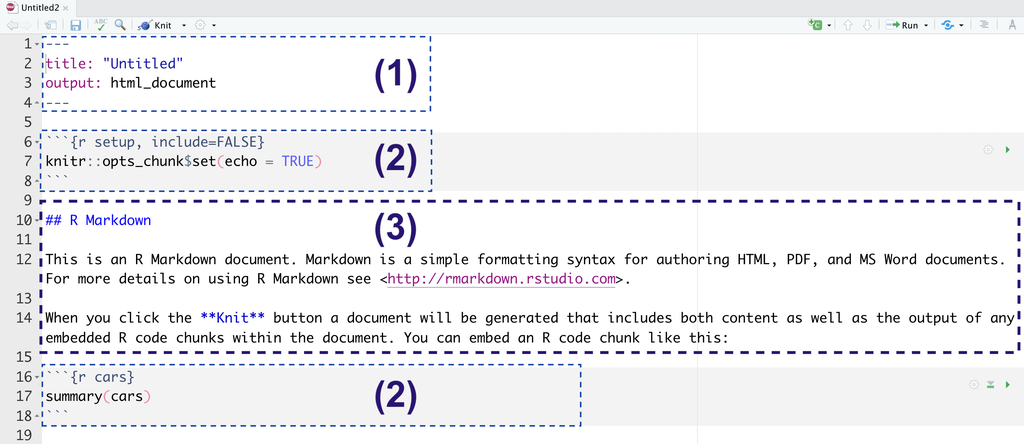

## 2.1 YAML

Aqui você irá configurar o estilo e propriedades do HTML que será gerado. Deixo dois sites se quiser personalizar do seu jeito o HTML:

https://cran.r-project.org/web/packages/ymlthis/vignettes/yaml-overview.html

https://zsmith27.github.io/rmarkdown_crash-course/lesson-4-yaml-headers.html

Segue o exemplo que utilizo:

```
---
title: "Markdown - Aula 0"
author: "Fabrício"
date: "2023-04-25"
output:
  html_document:
    number_sections: yes
    highlight: tango
    theme: cerulean
    toc: yes
    toc_float:
      collapsed: yes
      smmoth_scroll: no
  pdf_document:
    toc: yes
---
```

## 2.2 Markdown

### 2.2.1 Títulos

Podemos criar títulos colocando `#`, como podemos ver em todo esse arquivo:

```
# Título 1
## Título 2
### Título 3
#### Título 4
##### Título 5
```

### 2.2.2 Ênfase

#### 2.2.2.1 Negrito

Para destacar um **texto** em **negrito**, coloque `**` ou `__` ao redor do texto.

#### 2.2.2.2 Itálico

Para destacar um *texto* em *itálico*, coloque `*` ou `_` ao redor do texto.

#### 2.2.2.3 Riscado

Para riscar/tachar um texto , coloque `~~` ao redor do texto.

### 2.2.3 Listas

Você pode fazer uma lista ordenada usando somente números. Você pode repetir o número quantas vezes quiser:

Como é escrito no código:

```
1. Maçã

2. Banana

3. Uva
```

1. Maçã
2. Banana
3. Uva

Você pode fazer uma lista não ordenada escrevendo com hífens ou asteriscos, como a seguir:

```
* Maçã

* Banana

* Uva
```

- Maçã
- Banana
- Uva

Você também pode adicionar sub-itens na lista indicando a hierarquia através da identação no Markdown (dica: utilize a tecla tab do teclado):

```
* Maçã

  * Banana

* Uva
```

- Maçã
  - Banana
- Uva

### 2.2.4 Equações

Você pode adicionar equações utilizando LaTeX.

```
$$y = \mu + \sum_{i=1}^p \beta_i x_i + \epsilon$$
```

$$y = \mu + \sum_{i=1}^p \beta_i x_i +
\epsilon$$

Também é possível adicionar a equação na mesma linha que o texto, envolvendo o código com `$`. Veja o exemplo abaixo:

```
Ou também na linha $y = \mu + \sum_{i=1}^p \beta_i x_i + \epsilon$ , junto ao texto!
```

Ou também na linha $y = \mu + \sum_{i=1}^p \beta_i x_i + \epsilon$ , junto ao texto!

### 2.2.5 Código

Esse eu estou utilizando o tempo todo ao longo do arquivo.

Mas atenção: o texto será formatado como código, porém não será executado!

Como é escrito no código:

```
library(dados)
mean(pinguins$massa_corporal, na.rm = TRUE)
```

### 2.2.6 Links

Você pode criar um link utilizando esta estrutura:

```
[github](https://github.com/FabricioVenturim)
```

[github](https://github.com/FabricioVenturim)

### 2.2.7 Imagens

Você pode incluir uma imagem utilizando esta estrutura:

```
![descricao da imagem](http://url-da-imagem.com)
```

[figure not shown]

Gato

### 2.2.8 Tabelas

Podemos gerar tabelas com o seguinte código:

[Site para gerar tabelas](https://www.tablesgenerator.com/markdown_tables)

```
| Nome  | Descrição             | Tipo   | Domínio |
|------:|----------------------:|-------:|--------:|
| Nome  | Nome da administração | String | A-Z     |
| Senha | Senha do aluno        | Int    | 0-9     |
```

| Nome | Descrição | Tipo | Domínio |
| --- | --- | --- | --- |
| Nome | Nome da administração | String | A-Z |
| Senha | Senha do aluno | Int | 0-9 |

## 2.3 Chunks

Agora que iremos criar os locais para nossos códigos. Podemos adicionar códigos nos nossos relatórios que geram os resultados, assim a cada vez que compilarmos o relatório, os códigos que geram estes resultados serão executados, e o relatório terá sempre os resultados atualizados.

É possível adicionar campos aperte ``Ctrl + alt + I`.

```r
# Imprime a mensagem "Olá, mundo!"
print("Ola, mundo!")
```

```
## [1] "Ola, mundo!"
```

Percebe-se que eu criar um chunk aparece um botão verde no lado esquerdo para rodar o códigio. Após apertar em Knit, ele irá rodar todos os códgios e salvará o output no HTML, mas você também pode ir rodando por aqui mesmo (o certo).

Mais alguns exemplos:

```r
# Cria um vetor com os números de 1 a 5
vetor <- c(1, 2, 3, 4, 5)

# Calcula a média do vetor
media <- mean(vetor)

# Imprime a média na tela
print(media)
```

```
## [1] 3
```

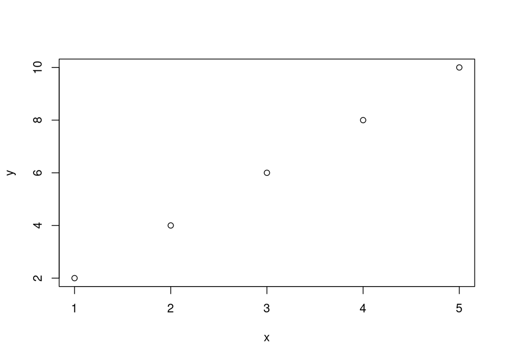

```r
# Cria um vetor com os valores de x
x <- c(1, 2, 3, 4, 5)

# Cria um vetor com os valores de y
y <- c(2, 4, 6, 8, 10)

# Faz um gráfico de dispersão com os valores de x e y
plot(x, y)
```

Com isso é suficiente para criar seus arquivos em R e realizar as atividades.

## 2.4 Básico de R e ggplot

Essa parte eu passei levemente na monitoria e vocês podem encontrar nos arquivos `NotasDeAula_R` e `NotasDeAula_ggplot2`.

## 2.5 Atividade

Deixo como atividade pegar `NotasDeAula_R` e `NotasDeAula_ggplot2` e fazer um resumo deles utilizando Markdown e ir testando os códigos aqui mesmo ou em um arquivo separado. Possivelmente a Asla já irá pedir para vocês fazerem isso em alguma atividade.

Por fim, fico grato por ter lido até aqui, qualquer dúvida pode me enviar pelo whatsapp :)